# Introducción a la programación y análisis de datos en R

Día 3 · Bloque 3 — ANOVA de una vía y ANOVA mixto: aov_car()

Filip Andras

CIMCYC — Universidad de Granada

23 octubre 2026

## Mapa del día 3

Bloque 1  
9:00 – 10:30

Datos anchos y largos

De ancho a largo: `pivot_longer()`

Ej. 1

De largo a ancho: `pivot_wider()`

Ej. 2

Tip: descriptivos de golpe

Bloque 2  
11:00 – 12:30

La fórmula en R: `VD ~ VI`

Correlación: `cor.test()`

Ej. 3

Comparar dos grupos: `t.test()`

Ej. 4

Bloque 3  
13:00 – 14:00 · 60’

ANOVA: Fisher y la *F*

ANOVA de una vía: `aov_car()`

Ej. 5

ANOVA mixto: interacción

# Más de dos grupos: ANOVA

## Un poco de historia: Fisher y la varianza

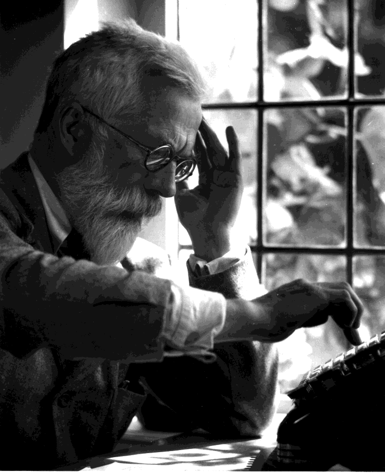

- **Ronald A. Fisher** (1890-1962), estadístico y genetista; desde 1919 en la **Rothamsted Experimental Station** (Inglaterra), el centro de investigación agrícola más antiguo del mundo
- Tenía que comparar el rendimiento de **muchas variedades de cultivo** a la vez; el *t*-test de Student solo sirve para **dos** grupos
- Su solución: no comparar las medias una a una, sino **descomponer la varianza total** en la parte que explican los grupos y la que no → **AN**alysis **O**f **VA**riance
- Lo publicó en *Statistical Methods for Research Workers* (1925); el estadístico se llama *F* en su honor

## La lógica: señal frente a ruido

$$F = \frac{\text{varianza ENTRE grupos (señal)}}{\text{varianza DENTRO de los grupos (ruido)}}$$

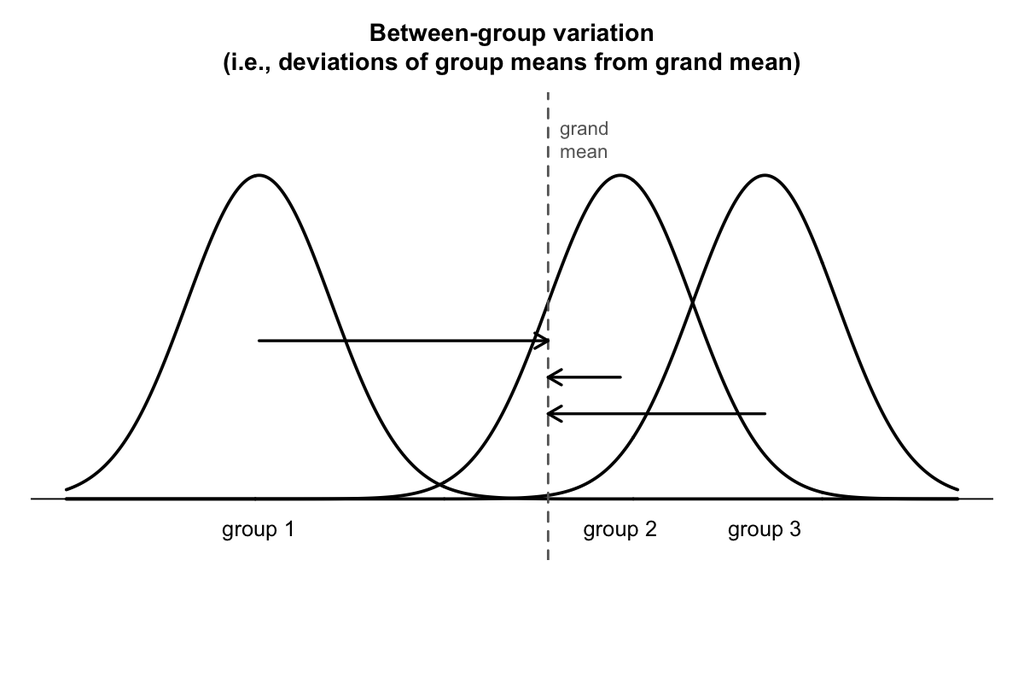

**Entre grupos**: ¿cuánto difieren las medias de los grupos?

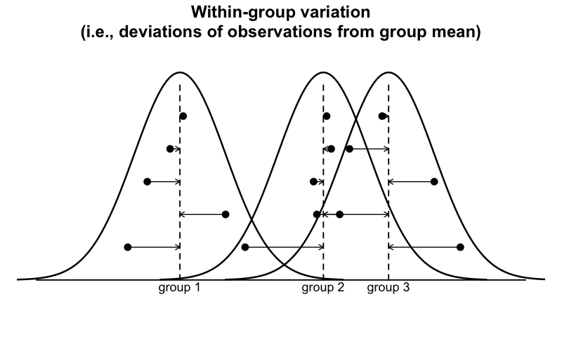

**Dentro de los grupos**: ¿cuánto varían los pacientes de un mismo grupo?

- Si $F \approx 1$: las medias no difieren más de lo que esperaríamos por azar
- Si $F \gg 1$: las diferencias entre grupos superan al ruido → hay efecto

## ¿Qué pinta tiene una *F* alta y una *F* baja?

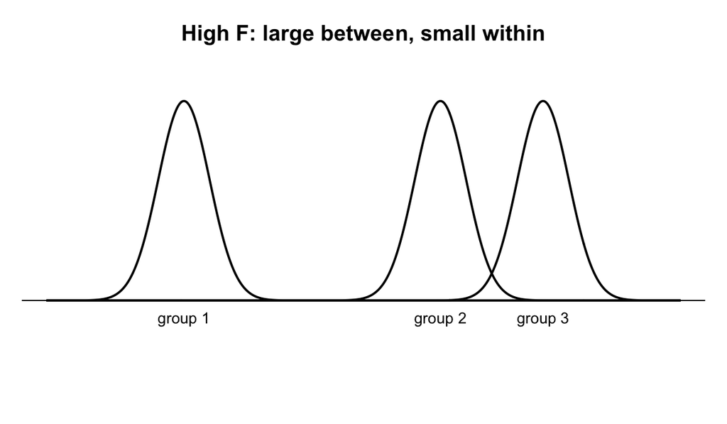

*F* alta — medias separadas, poca variabilidad interna: la señal supera al ruido

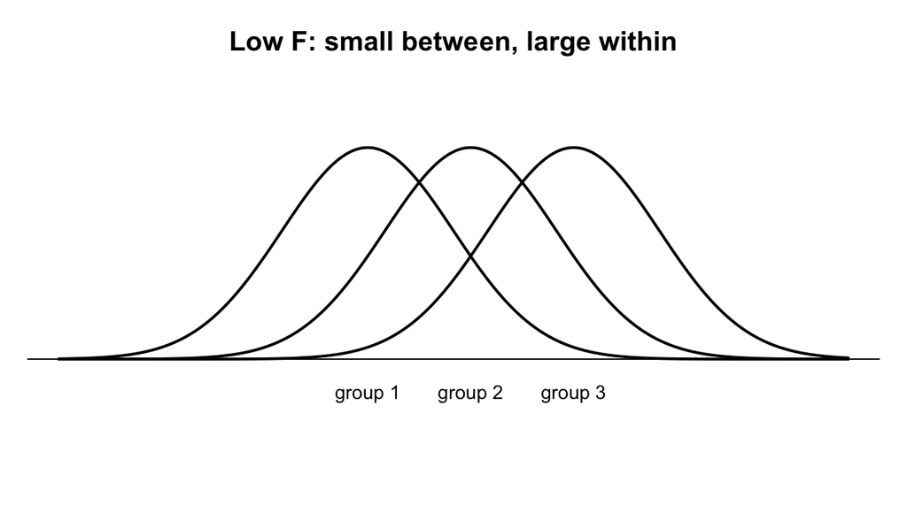

*F* baja — medias cercanas, mucha variabilidad interna: el ruido enmascara la señal

## Cuando la señal supera al ruido

Tres grupos (n = 10 cada uno, mismo ruido en todos los fotogramas) cuyas medias se van separando. A la derecha, la *F* observada avanza por la distribución *F*(2, 27) bajo $H_0$: cuando cruza la *F* crítica (3.35), el p-valor baja de .05. Con pocos datos hace falta mucha separación para que la señal supere al ruido.

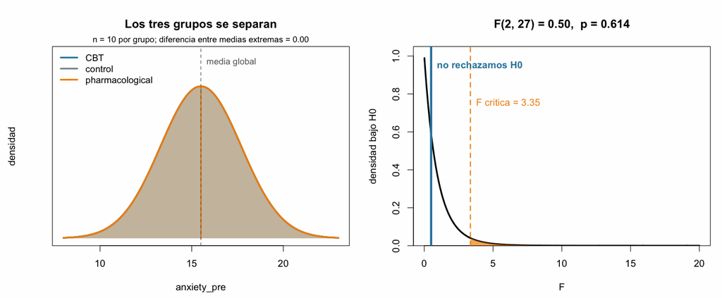

## Del *t*-test al ANOVA

Con **dos** grupos, el ANOVA y el *t*-test de Student dan el mismo resultado: $F = t^2$.

```r
# los dos grupos del bloque 2
datos_2grupos <- data_trial |>
  filter(group %in% c("pharmacological",
                      "control"))

# t de Student (varianzas iguales) al cuadrado
# $statistic extrae el valor t del resultado
t_student <- t.test(
  formula   = anxiety_pre ~ group,
  data      = datos_2grupos,
  var.equal = TRUE
)
t_student$statistic^2
```

```
         t
0.07164427
```

```r
# ANOVA con los mismos dos grupos
anova_2grupos <- aov_car(
  formula = anxiety_pre ~ group + Error(patient_id),
  data    = datos_2grupos
)
anova_2grupos
```

```
Anova Table (Type 3 tests)

Response: anxiety_pre
  Effect     df  MSE    F   ges p.value
1  group 1, 198 4.69 0.07 <.001    .789
---
Signif. codes:  0 '***' 0.001 '**' 0.01 '*' 0.05 '+' 0.1 ' ' 1
```

El ANOVA **generaliza** el *t*-test a más de dos grupos: primero pregunta si **alguna** media difiere (prueba *ómnibus*) y después, si procede, **cuáles** (post-hoc).

## Tres ANOVAs

| ANOVA | Pregunta | Ejemplo en el RCT | Código en R |
| --- | --- | --- | --- |
| Una vía (*between*) | ¿Difieren *k* grupos? | CBT, farmacológico y control en ansiedad pre | `aov_car(formula =``anxiety_pre``~``group``+ Error(``patient_id``),` `data = data_trial)` |
| Medidas repetidas (*within*) | ¿Cambia el mismo paciente entre momentos? | Ansiedad pre frente a post, un solo grupo | `aov_car(formula =``anxiety``~``momento``+ Error(``patient_id``/``momento``),` `data = datos_largo)` |
| Mixto (*between* × *within*) | ¿El cambio depende del grupo? | Ansiedad pre frente a post en los tres grupos | `aov_car(formula =``anxiety``~``group``*``momento``+ Error(``patient_id``/``momento``),` `data = datos_largo)` |

Hoy: el de **una vía** (juntos y en el Ejercicio 5) y el **mixto** (juntos).

`Error()` le dice a R quién es cada paciente: `Error(patient_id)` = una medida por paciente; `Error(patient_id/momento)` = varias medidas (`momento`) **dentro** de cada paciente. Los diseños *within* y mixto necesitan el formato **largo**.

## ¿Por qué `aov_car()` y no `aov()`?

| Función | Paquete | Sumas de cuadrados | Medidas repetidas | Esfericidad |
| --- | --- | --- | --- | --- |
| `aov()` | base R | Tipo I (depende del orden de los factores) | No (solo *between*) | No |
| `car::Anova()` | car | Tipo II / III | No directamente | No |
| **`afex::aov_car()`** | **afex** | **Tipo III** (correcto con grupos desiguales) | **Sí** | **Greenhouse-Geisser automática** |

**Tip**

`aov_car()` usa la **misma fórmula** que `t.test()` y `boxplot()`, maneja medidas repetidas y se integra con `emmeans` para los post-hoc. Para los tipos de sumas de cuadrados, ver Navarro, [*Learning Statistics with R*, cap. 16.10](https://learningstatisticswithr.com/book/anova2.html).

# ANOVA de una vía: `aov_car()`

## Pregunta: ¿difieren los tres grupos antes del tratamiento?

En el bloque 2 comparamos **dos** grupos con `t.test()`; con **tres**, el ANOVA de una vía.

```r
# los tres grupos del ensayo
pacientes_por_grupo <- data_trial |>
  count(group)
pacientes_por_grupo
```

```
# A tibble: 3 x 2
  group               n
  <chr>           <int>
1 CBT               100
2 control           100
3 pharmacological   100
```

**¿Qué esperamos?**

Que **no** haya diferencias en la ansiedad basal (pre): la asignación aleatoria debería dejar los tres grupos equivalentes antes del tratamiento.

## Paso 1: descriptivos por grupo

```r
# media, desviacion tipica y n por grupo
descriptivos_basal <- data_trial |>
  summarise(
    n     = n(),
    media = round(mean(anxiety_pre), 2),
    sd    = round(sd(anxiety_pre), 2),
    .by   = group
  )
descriptivos_basal
```

```
# A tibble: 3 x 4
  group               n media    sd
  <chr>           <int> <dbl> <dbl>
1 CBT               100  15.1  2.14
2 pharmacological   100  15.6  2.19
3 control           100  15.7  2.14
```

## Paso 2: visualizar

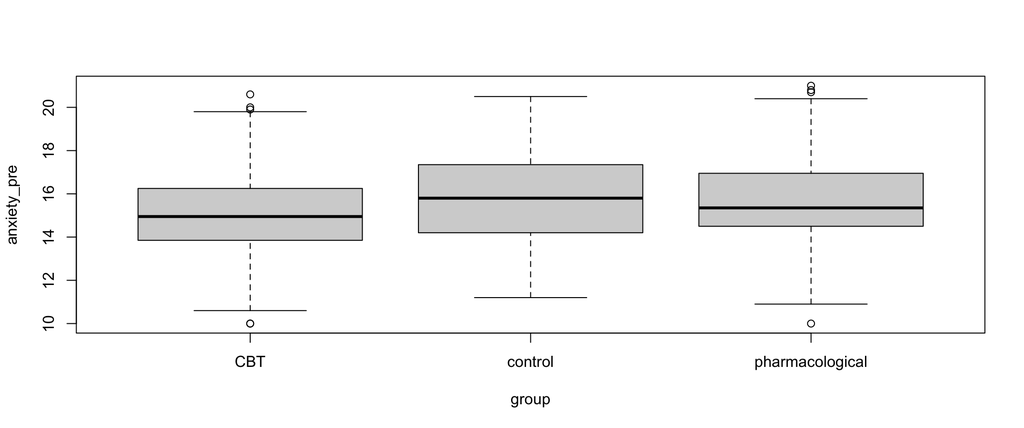

```r
# ansiedad pre en funcion del grupo
boxplot(formula = anxiety_pre ~ group,
        data = data_trial)
```

## Paso 3: ajustar el ANOVA con `aov_car()`

```r
# ANOVA de una via
# Error(patient_id): una medida por paciente
# include_aov = TRUE: guarda tambien el aov clasico
#   (lo necesita report() mas adelante)
anova_basal <- aov_car(
  formula     = anxiety_pre ~ group + Error(patient_id),
  data        = data_trial,
  include_aov = TRUE
)
anova_basal
```

```
Anova Table (Type 3 tests)

Response: anxiety_pre
  Effect     df  MSE      F  ges p.value
1  group 2, 297 4.66 2.73 + .018    .067
---
Signif. codes:  0 '***' 0.001 '**' 0.01 '*' 0.05 '+' 0.1 ' ' 1
```

- **df**: 2 (grupos − 1) y 297 (pacientes − grupos)
- **F**: señal / ruido
- **ges**: tamaño del efecto (η² generalizado)
- **p.value**: la probabilidad de una *F* así de grande si las tres medias fueran iguales

Ajustamos el modelo **antes** de comprobar los supuestos porque estos se evalúan sobre sus **residuos**.

## ¿Dónde cae nuestra *F*?

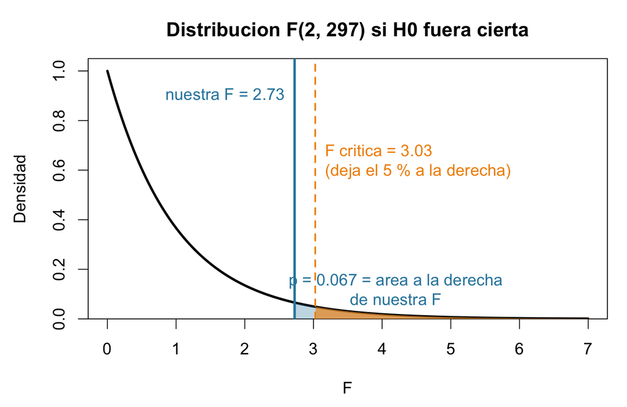

```r
# F critica: deja el 5 % a la derecha
qf(p = 0.95, df1 = 2, df2 = 297)
```

```
[1] 3.026153
```

```r
# p-valor: area a la derecha de la F
# ($ saca la F de la tabla del modelo)
pf(q   = anova_basal$anova_table$F,
   df1 = 2, df2 = 297,
   lower.tail = FALSE)
```

```
[1] 0.06714916
```

- La curva: cómo se repartiría *F* si $H_0$ fuera cierta (las tres medias iguales)
- Zona naranja: el 5 % más extremo; empieza en la *F* crítica
- Nuestra *F* queda a la **izquierda** de la crítica: no entra en la zona de rechazo
- El **p-valor** es el área a la derecha de nuestra *F*: .067 > .05

## Paso 4: supuestos (1/2): normalidad de los residuos

Un **residuo** es lo que el modelo no explica: la puntuación de cada paciente menos la media de su grupo. El ANOVA supone que los **residuos** siguen una distribución normal.

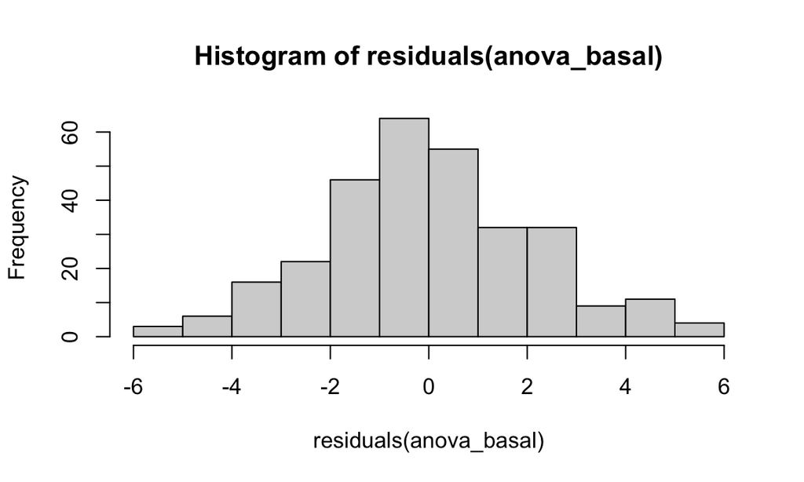

```r
# histograma de los residuos
hist(x = residuals(anova_basal))
```

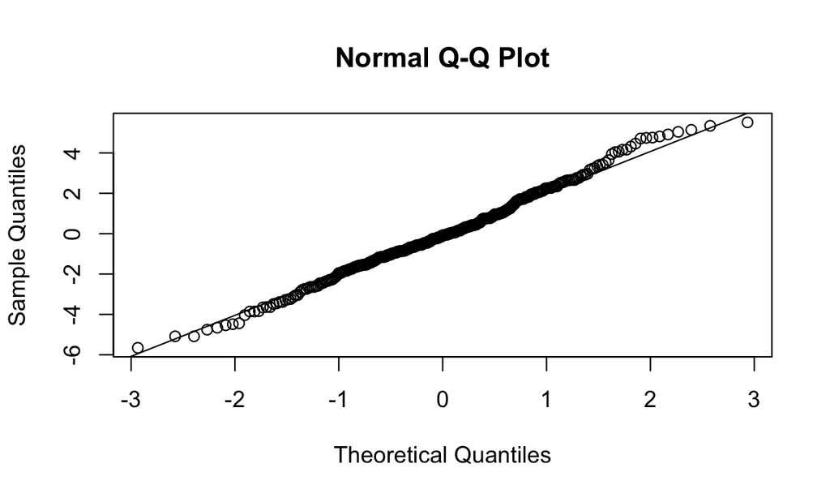

```r
# QQ plot de los residuos
qqnorm(y = residuals(anova_basal))
qqline(y = residuals(anova_basal))
```

## Paso 4: supuestos (2/2): tests

```r
# normalidad de los residuos (Shapiro-Wilk)
shapiro.test(x = residuals(anova_basal))
```

```
    Shapiro-Wilk normality test

data:  residuals(anova_basal)
W = 0.99367, p-value = 0.2413
```

```r
# homogeneidad de varianzas (Levene)
# H0: las varianzas de los tres grupos son iguales
levene_basal <- leveneTest(
  y    = anxiety_pre ~ group,
  data = data_trial
)
levene_basal
```

```
Levene's Test for Homogeneity of Variance (center = median)
       Df F value Pr(>F)
group   2  0.1905 0.8266
      297
```

- Shapiro-Wilk p > 0.05 → los residuos son compatibles con la normalidad (con 300 pacientes, mira también el QQ plot)
- Levene p > 0.05 → no hay evidencia de que las varianzas difieran (no demuestra que sean iguales)

## Paso 5: interpretar la tabla

- $H_0$: $\mu_{CBT} = \mu_{farmacológico} = \mu_{control}$ — las tres medias basales son iguales
- $H_1$: al menos una media difiere de las demás
- Resultado: *F*(2, 297) = 2.73, **p = .067** → **no significativo**: no rechazamos $H_0$
- No hay evidencia de diferencias basales entre grupos: la aleatorización funcionó

**Sin ómnibus significativo, no hay post-hoc**

Las comparaciones por pares solo se hacen cuando el ANOVA es significativo. Si no lo es, hacerlas aumenta la probabilidad de un falso positivo y no está justificado.

## Paso 6: tamaño del efecto

```r
# eta cuadrado: proporcion de la varianza de la VD explicada por el factor
eta_squared(model = anova_basal)
```

```
# Effect Size for ANOVA (Type III)

Parameter | Eta2 |       95% CI
-------------------------------
group     | 0.02 | [0.00, 1.00]

- One-sided CIs: upper bound fixed at [1.00].
```

- Es la columna **ges** de la tabla de `aov_car()`: con un solo factor, η² generalizado = η²
- Referencias de Cohen (1988): 0.01 pequeño, 0.06 mediano, 0.14 grande

## Paso 7: `report::report()` — reportar el ANOVA

```r
# resumen APA sobre el aov clasico guardado dentro del modelo
report(x = anova_basal$aov)
```

```
The ANOVA (formula: anxiety_pre ~ group) suggests that:

  - The main effect of group is statistically not significant and small (F(2, 297) = 2.73, p = 0.067; Eta2 = 0.02, 95% CI
[0.00, 1.00])

Effect sizes were labelled following Field's (2013) recommendations.
```

**Tip**

`report()` todavía no admite objetos de `afex`; por eso pedimos `include_aov = TRUE` en `aov_car()` y le pasamos `anova_basal$aov`.

## Ejercicio 5 — ANOVA después del tratamiento

Tiempo: 12 minutos

Mismo flujo que el ANOVA basal, ahora con `anxiety_post`: ¿difieren los tres grupos **después** del tratamiento?

1. Calcula n, media y desviación típica de `anxiety_post` por grupo
2. Visualiza con `boxplot()` y la fórmula `anxiety_post ~ group`
3. Ajusta el ANOVA con `aov_car()` (`include_aov = TRUE`) y guárdalo en `anova_post`
4. Supuestos: histograma, QQ plot y `shapiro.test()` de los residuos; `leveneTest()`
5. ¿Es significativo `group`? Si lo es: post-hoc con `emmeans()` + `pairs()` (Holm)
6. Tamaño del efecto con `eta_squared()` y resumen con `report()` sobre `anova_post$aov`

# ANOVA mixto: grupo × momento

## Un factor *between* y un factor *within*

| Factor | Tipo | Por qué |
| --- | --- | --- |
| `group` | *between* (entre-sujetos) | Cada paciente está en **un solo** grupo: CBT, farmacológico o control |
| `momento` | *within* (intra-sujeto) | Cada paciente se mide **dos veces**: pre y post (hoy ignoramos el seguimiento) |

- El ANOVA de una vía miró **un momento** → ignora el cambio
- El ANOVA mixto combina los dos factores y hace la pregunta clave: **¿el cambio pre → post depende del grupo?** Eso es la **interacción** `group:momento`

## Formato largo: una fila por medida

```r
# de ancho a largo: una fila por medida
datos_largo <- data_trial |>
  select(patient_id, group,
         anxiety_pre, anxiety_post) |>
  pivot_longer(
    cols         = c(anxiety_pre, anxiety_post),
    names_to     = "momento",
    values_to    = "anxiety",
    # quita el prefijo: "anxiety_pre" -> "pre"
    names_prefix = "anxiety_"
  ) |>
  # factor() fija el orden: pre antes que post
  mutate(momento = factor(momento,
                          levels = c("pre", "post")))

# 300 pacientes x 2 momentos = 600 filas
nrow(datos_largo)
```

```
[1] 600
```

```r
head(datos_largo)
```

```
# A tibble: 6 x 4
  patient_id group momento anxiety
       <dbl> <chr> <fct>     <dbl>
1          1 CBT   pre        20
2          1 CBT   post       16.6
3          2 CBT   pre        17.7
4          2 CBT   post       12.3
5          3 CBT   pre        15.5
6          3 CBT   post       11
```

Lo mismo que hicimos en el **bloque 1**: los diseños con medidas repetidas necesitan **una fila por medida**.

## ¿Qué es una interacción?

El efecto de un factor **depende del nivel** del otro: ¿el cambio pre → post es **distinto** según el grupo?

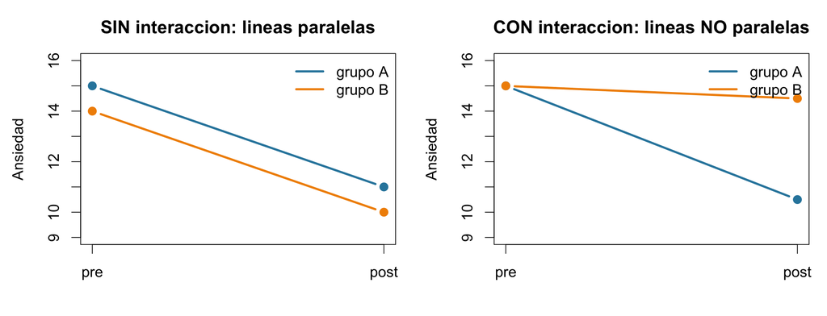

- **Paralelas**: los dos grupos cambian **igual** → no hay interacción (solo efectos principales)
- **No paralelas**: el cambio **depende** del grupo → hay interacción

## La fórmula del ANOVA mixto

```r
aov_car(formula = anxiety ~ group * momento + Error(patient_id/momento),
        data    = datos_largo)
```

- `anxiety ~ group * momento`: el `*` pide los dos **efectos principales** y la **interacción** (`group:momento`)
- `Error(patient_id/momento)`: las medidas de `momento` están **dentro** de cada `patient_id` (medidas repetidas)
- `data = datos_largo`: una fila por medida

## `aov_car()`: ajustar el ANOVA mixto

```r
# ANOVA mixto: group (between) x momento (within)
anova_mixto <- aov_car(
  formula = anxiety ~ group * momento + Error(patient_id/momento),
  data    = datos_largo
)
anova_mixto
```

```
Anova Table (Type 3 tests)

Response: anxiety
         Effect     df   MSE          F  ges p.value
1         group 2, 297 10.62  29.99 *** .153   <.001
2       momento 1, 297  1.29 788.06 *** .223   <.001
3 group:momento 2, 297  1.29 138.91 *** .092   <.001
---
Signif. codes:  0 '***' 0.001 '**' 0.01 '*' 0.05 '+' 0.1 ' ' 1
```

- **group**: ¿difieren los grupos en ansiedad, promediando pre y post?
- **momento**: ¿cambia la ansiedad de pre a post, promediando los grupos?
- **group:momento**: ¿el cambio pre → post **depende** del grupo? ← **la pregunta del ensayo**

## Interpretar una interacción

**Regla de interpretación**

Si la **interacción** es significativa, los efectos principales por sí solos engañan: “la ansiedad baja de pre a post” es cierto en promedio, pero **no baja igual en todos los grupos**. Hay que **descomponer** la interacción: gráfico + efectos simples.

Supuestos del ANOVA mixto, ya comprobados hoy:

- **Normalidad** de los residuos y **homogeneidad de varianzas** en cada momento: el ANOVA basal (pre) y el Ejercicio 5 (post)
- **Esfericidad**: que las diferencias entre momentos (post − pre, seg − pre, seg − post) varíen igual entre pacientes. Con dos momentos solo hay **una** diferencia (post − pre): no hay nada que comparar, el supuesto se cumple solo
- Con **tres o más** niveles, `aov_car()` aplica **siempre** la corrección de Greenhouse-Geisser (los df dejan de ser enteros): lo veréis en el Ejercicio 6

## Visualizar la interacción: `emmip()`

```r
# emmip() = estimated marginal means interaction plot
# medias estimadas por el modelo, con intervalos de confianza
emmip(object = anova_mixto, formula = group ~ momento, CIs = TRUE)
```

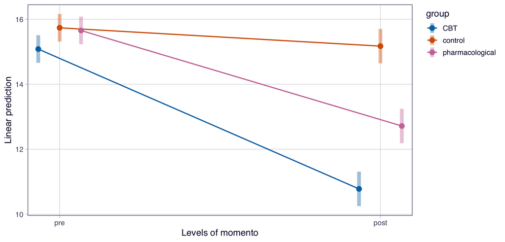

Las líneas **no son paralelas**: CBT baja mucho, farmacológico bastante, control apenas. Eso es la interacción.

## Efectos simples (1/2): ¿difieren los grupos?

```r
# los tres grupos EN CADA momento (pre y post)
grupos_por_momento <- emmeans(object = anova_mixto, specs = ~ group | momento)
pairs(x = grupos_por_momento, adjust = "holm")
```

```
momento = pre:
 contrast                  estimate    SE  df t.ratio p.value
 CBT - control               -0.654 0.305 297  -2.143  0.0988
 CBT - pharmacological       -0.572 0.305 297  -1.874  0.1238
 control - pharmacological    0.082 0.305 297   0.269  0.7884

momento = post:
 contrast                  estimate    SE  df t.ratio p.value
 CBT - control               -4.393 0.381 297 -11.539 <0.0001
 CBT - pharmacological       -1.936 0.381 297  -5.085 <0.0001
 control - pharmacological    2.457 0.381 297   6.454 <0.0001

P value adjustment: holm method for 3 tests
```

- Fíjate en los **estimates** (la diferencia de medias de cada pareja)
- **pre**: diferencias de menos de **1 punto**, ninguna significativa — lo mismo que el ANOVA basal
- **post**: diferencias de **2 a 4 puntos**, las tres significativas — lo mismo que el Ejercicio 5

## Efectos simples (2/2): ¿cambia cada grupo?

```r
# medias por momento DENTRO de cada grupo (| = "dentro de")
cambio_por_grupo <- emmeans(object = anova_mixto, specs = ~ momento | group)

# pre frente a post en cada grupo (correccion de Holm)
pairs(x = cambio_por_grupo, adjust = "holm")
```

```
group = CBT:
 contrast   estimate    SE  df t.ratio p.value
 pre - post    4.303 0.161 297  26.803 <0.0001

group = control:
 contrast   estimate    SE  df t.ratio p.value
 pre - post    0.564 0.161 297   3.513  0.0005

group = pharmacological:
 contrast   estimate    SE  df t.ratio p.value
 pre - post    2.939 0.161 297  18.307 <0.0001
```

- Fíjate en los **estimates** (pre − post: cuánto baja la ansiedad en cada grupo)
- Baja en los tres grupos (las tres comparaciones son significativas), pero el **tamaño** del cambio es muy distinto: CBT 4.3, farmacológico 2.9, control 0.6 puntos
- Que el cambio pre → post **dependa del grupo** es exactamente la **interacción** `group:momento`
- El cambio del control es significativo pero pequeño: ¿clínicamente relevante?

## Conclusiones del ANOVA mixto

**Lo que responde el ensayo**

- La **interacción grupo × momento** es significativa: el cambio pre → post **depende** del tratamiento
- **CBT** reduce la ansiedad más que el **farmacológico**, y ambos mucho más que el **control**
- Antes del tratamiento los grupos eran equivalentes; después, difieren todos entre sí

## Ejercicio 6 (para casa) — el seguimiento a los 3 meses

Para casa: unos 30 minutos

En clase ignoramos el seguimiento. Repite el ANOVA mixto con los **tres** momentos (pre, post, followup): ¿se **mantiene** la mejora a los 3 meses?

1. Carga `data/processed_data/preprocessed_data.csv` (tiene `anxiety_followup`)
2. Pivota `anxiety_pre`, `anxiety_post` y `anxiety_followup` a formato largo (`momento`, `anxiety`); `momento` como factor con los niveles pre, post, followup
3. Media y desviación típica de `anxiety` por `group` y `momento`
4. ANOVA mixto con `aov_car()`: `anxiety ~ group * momento + Error(patient_id/momento)`. Fíjate en los df de `momento`: con tres niveles `aov_car()` aplica la corrección de **Greenhouse-Geisser** (esfericidad)
5. Gráfico de interacción con `emmip()`
6. Efectos simples: momentos dentro de cada grupo con `emmeans()` + `pairs()` (Holm). ¿Qué grupo mantiene la mejora y cuál vuelve al nivel inicial?

La solución está en `03_day3_exercises_solutions.R` (Ejercicio 6), que se publicará antes de la sesión 4.

## Resumen del bloque 3

ANOVA: la lógica

`F = señal / ruido``F = t²``t.test()`

ANOVA de una vía: `aov_car()`

`aov_car()``Error(patient_id)``include_aov = TRUE``residuals()``shapiro.test()``leveneTest()``eta_squared()``report()`

Post-hoc

`emmeans()``pairs()``adjust = "holm"`

ANOVA mixto

`pivot_longer()``group * momento``Error(patient_id/momento)``emmip()``~ momento | group`

Con borde naranja: funciones **nuevas** de este bloque.

# Mentimeter

## Mentimeter ¿Cómo ha ido el día?

Escanea el código QR o entra en menti.com y escribe el código:

**7952 6302**

Dos minutos de feedback: qué ha quedado claro, qué no, y qué cambiarías para la próxima sesión.

[figure not shown]

## Próxima sesión (30 de octubre)

Visualización de datos con `ggplot2` y reportes reproducibles con Quarto.